# Cancelamento Telecom

Marcio Cruz

08/07/2021

## Case

Um diretor encarregado da tarefa de retenção de clientes de uma Telecom deseja criar um modelo para calcular a probabilidade de o cliente cancelar sua conta, a fim de realizar ações de retenção ativa.

## a) Faça a análise exploratória univariada e interprete todas as variáveis do banco de dados.

```
##   Score_serasa       Sexo               Idade       Tempo_relacionamento
##  Min.   :350.0   Length:10000       Min.   :18.00   Min.   : 0.000
##  1st Qu.:584.0   Class :character   1st Qu.:32.00   1st Qu.: 3.000
##  Median :652.0   Mode  :character   Median :37.00   Median : 5.000
##  Mean   :650.5                      Mean   :38.92   Mean   : 5.013
##  3rd Qu.:718.0                      3rd Qu.:44.00   3rd Qu.: 7.000
##  Max.   :850.0                      Max.   :92.00   Max.   :10.000
##  Possui_internet  Salario_anual          Cancelou
##  Min.   :0.0000   Min.   :    11.58   Min.   :0.0000
##  1st Qu.:0.0000   1st Qu.: 51002.11   1st Qu.:0.0000
##  Median :1.0000   Median :100193.91   Median :0.0000
##  Mean   :0.7055   Mean   :100090.24   Mean   :0.2037
##  3rd Qu.:1.0000   3rd Qu.:149388.25   3rd Qu.:0.0000
##  Max.   :1.0000   Max.   :199992.48   Max.   :1.0000
```

#### Variável Sexo

```
##
## Female   Male
##   4543   5457
```

```
##
## Female   Male
## 0.4543 0.5457
```

#### Variável Idade

```
##    Min. 1st Qu.  Median    Mean 3rd Qu.    Max.
##   18.00   32.00   37.00   38.92   44.00   92.00
```

#### Variável Tempo Relacionamento

```
##    Min. 1st Qu.  Median    Mean 3rd Qu.    Max.
##   0.000   3.000   5.000   5.013   7.000  10.000
```

#### Variável Possui Internet

```
##
##    0    1
## 2945 7055
```

```
##
##      0      1
## 0.2945 0.7055
```

#### Variável Cancelou

```
##
##    0    1
## 7963 2037
```

```
##
##      0      1
## 0.7963 0.2037
```

#### Variável Salário Anual

```
##      Min.   1st Qu.    Median      Mean   3rd Qu.      Max.
##     11.58  51002.11 100193.91 100090.24 149388.25 199992.48
```

#### Variável Score Serasa

```
##    Min. 1st Qu.  Median    Mean 3rd Qu.    Max.
##   350.0   584.0   652.0   650.5   718.0   850.0
```

## b) Faça a análise bivariada das variáveis explicativas (covariáveis) vs. a variável resposta. Interprete os resultados.

#### Variáveis quantitativas

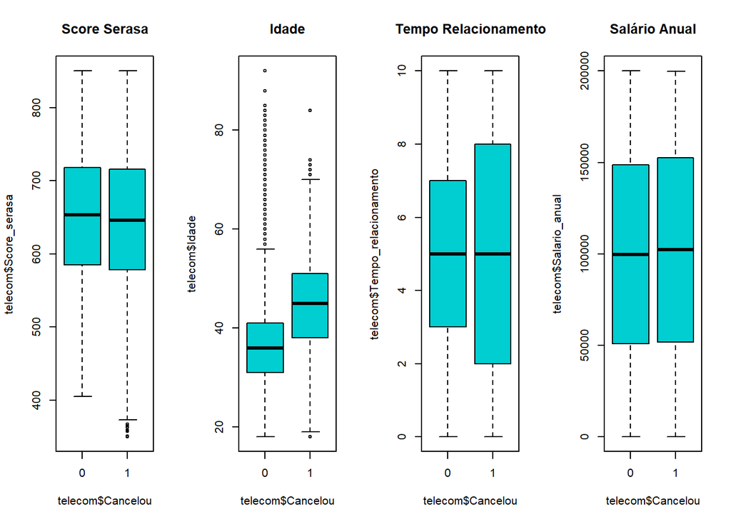

#### Variáveis qualitativas

```
##
##              0     1
##   Female 0.749 0.251
##   Male   0.835 0.165
```

```
##
##         0     1
##   0 0.792 0.208
##   1 0.798 0.202
```

## C) Obtenha o modelo de regressão logística utilizando 90% de confiança.

#### Todas as variáveis

```
##
## Call:
## glm(formula = Cancelou ~ Score_serasa + Sexo + Idade + Tempo_relacionamento +
##     Possui_internet + Salario_anual, family = binomial(link = "logit"),
##     data = telecom)
##
## Deviance Residuals:
##     Min       1Q   Median       3Q      Max
## -1.8991  -0.6615  -0.5295  -0.3942   2.5230
##
## Coefficients:
##                           Estimate    Std. Error z value             Pr(>|z|)
## (Intercept)          -3.1730952394  0.2172608406 -14.605 < 0.0000000000000002
## Score_serasa         -0.0007663880  0.0002698968  -2.840              0.00452
## SexoMale             -0.5366564307  0.0523817657 -10.245 < 0.0000000000000002
## Idade                 0.0631433418  0.0023816231  26.513 < 0.0000000000000002
## Tempo_relacionamento -0.0094070704  0.0090086650  -1.044              0.29638
## Possui_internet      -0.0216762094  0.0570602154  -0.380              0.70403
## Salario_anual         0.0000006609  0.0000004559   1.450              0.14714
##
## (Intercept)          ***
## Score_serasa         **
## SexoMale             ***
## Idade                ***
## Tempo_relacionamento
## Possui_internet
## Salario_anual
## ---
## Signif. codes:  0 '***' 0.001 '**' 0.01 '*' 0.05 '.' 0.1 ' ' 1
##
## (Dispersion parameter for binomial family taken to be 1)
##
##     Null deviance: 10109.8  on 9999  degrees of freedom
## Residual deviance:  9233.4  on 9993  degrees of freedom
## AIC: 9247.4
##
## Number of Fisher Scoring iterations: 4
```

#### Retirar Possui Internet

```
##
## Call:
## glm(formula = Cancelou ~ Score_serasa + Sexo + Idade + Tempo_relacionamento +
##     Salario_anual, family = binomial(link = "logit"), data = telecom)
##
## Deviance Residuals:
##     Min       1Q   Median       3Q      Max
## -1.8928  -0.6617  -0.5297  -0.3945   2.5207
##
## Coefficients:
##                           Estimate    Std. Error z value             Pr(>|z|)
## (Intercept)          -3.1888706422  0.2132817003 -14.951 < 0.0000000000000002
## Score_serasa         -0.0007656145  0.0002698846  -2.837              0.00456
## SexoMale             -0.5366860336  0.0523813695 -10.246 < 0.0000000000000002
## Idade                 0.0631512883  0.0023815810  26.517 < 0.0000000000000002
## Tempo_relacionamento -0.0094843022  0.0090064486  -1.053              0.29231
## Salario_anual         0.0000006621  0.0000004559   1.452              0.14639
##
## (Intercept)          ***
## Score_serasa         **
## SexoMale             ***
## Idade                ***
## Tempo_relacionamento
## Salario_anual
## ---
## Signif. codes:  0 '***' 0.001 '**' 0.01 '*' 0.05 '.' 0.1 ' ' 1
##
## (Dispersion parameter for binomial family taken to be 1)
##
##     Null deviance: 10109.8  on 9999  degrees of freedom
## Residual deviance:  9233.6  on 9994  degrees of freedom
## AIC: 9245.6
##
## Number of Fisher Scoring iterations: 4
```

#### Retirar Tempo Relacionamento

```
##
## Call:
## glm(formula = Cancelou ~ Score_serasa + Sexo + Idade + Salario_anual,
##     family = binomial(link = "logit"), data = telecom)
##
## Deviance Residuals:
##     Min       1Q   Median       3Q      Max
## -1.8921  -0.6620  -0.5304  -0.3948   2.5136
##
## Coefficients:
##                    Estimate    Std. Error z value             Pr(>|z|)
## (Intercept)   -3.2357974840  0.2086510316 -15.508 < 0.0000000000000002 ***
## Score_serasa  -0.0007654755  0.0002698714  -2.836              0.00456 **
## SexoMale      -0.5375128399  0.0523732948 -10.263 < 0.0000000000000002 ***
## Idade          0.0631652570  0.0023814641  26.524 < 0.0000000000000002 ***
## Salario_anual  0.0000006565  0.0000004558   1.440              0.14977
## ---
## Signif. codes:  0 '***' 0.001 '**' 0.01 '*' 0.05 '.' 0.1 ' ' 1
##
## (Dispersion parameter for binomial family taken to be 1)
##
##     Null deviance: 10109.8  on 9999  degrees of freedom
## Residual deviance:  9234.7  on 9995  degrees of freedom
## AIC: 9244.7
##
## Number of Fisher Scoring iterations: 4
```

#### Retirar Salário Atual

```
##
## Call:
## glm(formula = Cancelou ~ Score_serasa + Sexo + Idade, family = binomial(link = "logit"),
##     data = telecom)
##
## Deviance Residuals:
##     Min       1Q   Median       3Q      Max
## -1.8864  -0.6624  -0.5312  -0.3949   2.5019
##
## Coefficients:
##                Estimate Std. Error z value             Pr(>|z|)
## (Intercept)  -3.1658807  0.2027739 -15.613 < 0.0000000000000002 ***
## Score_serasa -0.0007674  0.0002699  -2.843              0.00446 **
## SexoMale     -0.5380317  0.0523672 -10.274 < 0.0000000000000002 ***
## Idade         0.0631085  0.0023804  26.512 < 0.0000000000000002 ***
## ---
## Signif. codes:  0 '***' 0.001 '**' 0.01 '*' 0.05 '.' 0.1 ' ' 1
##
## (Dispersion parameter for binomial family taken to be 1)
##
##     Null deviance: 10109.8  on 9999  degrees of freedom
## Residual deviance:  9236.8  on 9996  degrees of freedom
## AIC: 9244.8
##
## Number of Fisher Scoring iterations: 4
```

### d) Obtenha a probabilidade estimada.

```r
telecom$probabilidade = predict(modelo, telecom, type = "response")
head(telecom)
```

```
## # A tibble: 6 x 9
##       ID Score_serasa Sexo  Idade Tempo_relaciona~ Possui_internet Salario_anual
##    <dbl>        <dbl> <chr> <dbl>            <dbl>           <dbl>         <dbl>
## 1 1.56e7          619 Fema~    42                2               1       101349.
## 2 1.56e7          608 Fema~    41                1               0       112543.
## 3 1.56e7          502 Fema~    42                8               1       113932.
## 4 1.57e7          699 Fema~    39                1               0        93827.
## 5 1.57e7          850 Fema~    43                2               1        79084.
## 6 1.56e7          645 Male     44                8               1       149757.
## # ... with 2 more variables: Cancelou <dbl>, probabilidade <dbl>
```

### e) Obtenha a tabela de classificacao utilizando o ponto de corte de 0,2. Qual o percentual de classificacao correta? E a sensibilidade e especificidade?

#### Aplicar a predição

```r
telecom$predito <- as.factor(ifelse(telecom$probabilidade > 0.2, 1, 0))
kable(head(telecom), caption="Head tabela")
```

Head tabela

| ID | Score_serasa | Sexo | Idade | Tempo_relacionamento | Possui_internet | Salario_anual | Cancelou | probabilidade | predito |
| --- | --- | --- | --- | --- | --- | --- | --- | --- | --- |
| 15634602 | 619 | Female | 42 | 2 | 1 | 101348.88 | 1 | 0.2708456 | 1 |
| 15647311 | 608 | Female | 41 | 1 | 0 | 112542.58 | 0 | 0.2601857 | 1 |
| 15619304 | 502 | Female | 42 | 8 | 1 | 113931.57 | 1 | 0.2889370 | 1 |
| 15701354 | 699 | Female | 39 | 1 | 0 | 93826.63 | 0 | 0.2242527 | 1 |
| 15737888 | 850 | Female | 43 | 2 | 1 | 79084.10 | 0 | 0.2488987 | 1 |
| 15574012 | 645 | Male | 44 | 8 | 1 | 149756.71 | 1 | 0.1943321 | 0 |

#### Tabela de Classificação (matriz de confusão)

Resposta Observada x Resposta Predita

|  | 0 | 1 |
| --- | --- | --- |
| 0 | 5555 | 2408 |
| 1 | 671 | 1366 |

#### Diagonais:

##### Diagonal Principal:6921.0000

##### Diagonal Secundária:3079.0000

##### Proporção: 2.2478

#### Índices:

##### Acurácia (vp+vn / vp+vn+fp+fn): 0.6921

##### Sensibilidade (vp/vp+fn): 0.6706

##### Especificidade (vn/vn+fp): 0.6976

#### Interpretação sobre o modelo

##### Apresenta bom ajuste, já que há concentração dos casos na diagonal principal, confirmado pela acurácia de: 69.21%

##### Sendo que o objetivo do modelo é descobrir quem cancelou, usaremos a referência do indicador de sensibilidade: 67.06%.

##### O resultado do índice de sensibilidade demonstra um valor satisfatório.

### f) Aplicar IV nas variáveis

IV

|  | Variable | IV |
| --- | --- | --- |
| 2 | Idade | 0.7840698 |
| 1 | Sexo | 0.0697749 |
| 6 | Score_serasa | 0.0109598 |
| 3 | Tempo_relacionamento | 0.0085965 |
| 5 | Salario_anual | 0.0023100 |
| 4 | Possui_internet | 0.0003126 |

### g) VIF

```r
modelo.vif <- vif(modelo)
kable(modelo.vif)
```

|  | x |
| --- | --- |
| Score_serasa | 1.000025 |
| SexoMale | 1.000768 |
| Idade | 1.000776 |

### h) Ponto de Corte com maximização da Acurácia

```
## Assuming the positive class is 1
```

```
## Assuming the positive class has higher x values
```

### i) Ponto de Corte com minimização da diferença entre especificidade e sensibilidade

```r
ponto <- cutpointr(telecom2, probabilidade, Cancelou,
                   method = minimize_metric, metric = abs_d_sens_spec)
```

```
## Assuming the positive class is 1
```

```
## Assuming the positive class has higher x values
```

```r
#summary(ponto)
```

O ponto de corte otimizado é 0.1967

### j) KS (Kolmogorov-Smirnov estatística)

```r
ks_stat(actuals = telecom2$Cancelou, predictedScores = telecom2$probabilidade)
```

```
## [1] 0.3676
```

### k) ROC

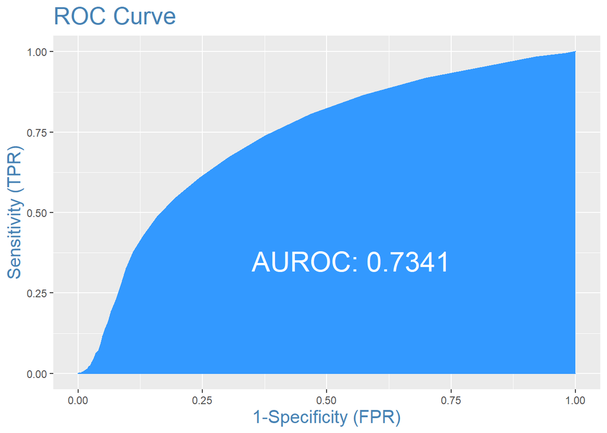

### l) Aplicando o corte para minimizar a diferença entre especificidade e sensibilidade

Resposta Observada x Resposta Predita

|  | 0 | 1 |
| --- | --- | --- |
| 0 | 5453 | 2510 |
| 1 | 643 | 1394 |